# Practical Machine Learning Course Project

# Clean the pml-training dataset by getting rid of the calculated features.

```r
temp1 <- select(pml_training, starts_with("roll"))
temp2 <- select(pml_training, starts_with("pitch"))
temp3 <- select(pml_training, starts_with("yaw"))
temp4 <- select(pml_training, starts_with("total"))
temp5 <- select(pml_training, starts_with("gyros"))
temp6 <- select(pml_training, starts_with("accel"))
temp7 <- select(pml_training, starts_with("magnet"))
temp8 <- select(pml_training, classe)
pml_training_new <- data.frame(temp1, temp2, temp3, temp4,temp5, temp6,
                               temp7, temp8)
```

Set seed and partition pml_training_new into train and test datasets.

```r
set.seed(95014)
inTraining <- createDataPartition(pml_training_new$classe, p = .75, list=FALSE)
training <- pml_training_new[inTraining,]
testing <- pml_training_new[-inTraining,]
```

Set up training run for x / y syntax because model format performs poorly.

```r
x_train <- training[,-53]
y_train <- training[,53]
x_test <- testing[,-53]
y_test <- testing[,53]
```

Configure parallel processing:

```r
library(parallel, quietly = TRUE)
library(doParallel, quietly = TRUE)
set.seed(22307)
cluster <- makeCluster(detectCores() - 1)
registerDoParallel(cluster)
```

Set fitControl parameters to do 10-fold cross validation (to estimate the test error associated with the model in order to evaluate its performance) and allow for parallel processing.

```r
fitControl <- trainControl(method="cv",
                           number = 10,
                           allowParallel = TRUE)
```

Run gradient boosting machine using default tuning parameters.

```r
fit1 <- train(x_train, y_train, method="gbm", trControl=fitControl,
              verbose=FALSE)
stopCluster(cluster)
```

The following chart shows the relationship between tuning parameters and the cross-validated accuracy of the model. In particular it shows that accuracy increases with the number of trees and that relationship shifts upward with greater tree depth. This chart will help inform the second model fit later in this report.

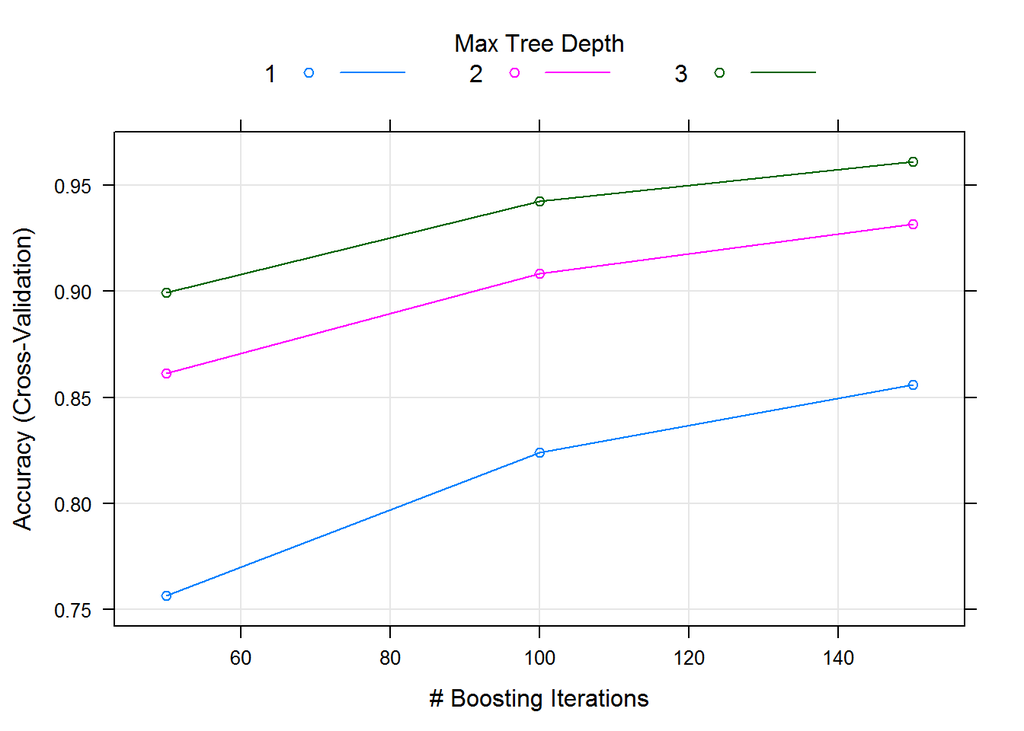

```r
plot(fit1)
```

The following summarizes the results of the fitted model.

```r
fit1
```

```
## Stochastic Gradient Boosting
##
## 14718 samples
##    52 predictor
##     5 classes: 'A', 'B', 'C', 'D', 'E'
##
## No pre-processing
## Resampling: Cross-Validated (10 fold)
## Summary of sample sizes: 13247, 13245, 13245, 13247, 13247, 13246, ...
## Resampling results across tuning parameters:
##
##   interaction.depth  n.trees  Accuracy   Kappa
##   1                   50      0.7564898  0.6913165
##   1                  100      0.8240932  0.7773467
##   1                  150      0.8558911  0.8176384
##   2                   50      0.8612604  0.8243015
##   2                  100      0.9082761  0.8839154
##   2                  150      0.9317840  0.9136814
##   3                   50      0.8994420  0.8726860
##   3                  100      0.9424510  0.9271760
##   3                  150      0.9609335  0.9505730
##
## Tuning parameter 'shrinkage' was held constant at a value of 0.1
##
## Tuning parameter 'n.minobsinnode' was held constant at a value of 10
## Accuracy was used to select the optimal model using  the largest value.
## The final values used for the model were n.trees = 150,
##  interaction.depth = 3, shrinkage = 0.1 and n.minobsinnode = 10.
```

```r
fit1$resample
```

```
##     Accuracy     Kappa Resample
## 1  0.9633152 0.9535771   Fold06
## 2  0.9632903 0.9535646   Fold09
## 3  0.9666893 0.9578404   Fold05
## 4  0.9694293 0.9613385   Fold08
## 5  0.9633401 0.9536095   Fold02
## 6  0.9598912 0.9492492   Fold04
## 7  0.9490835 0.9356206   Fold07
## 8  0.9646499 0.9552545   Fold10
## 9  0.9544528 0.9423872   Fold01
## 10 0.9551935 0.9432888   Fold03
```

```r
confusionMatrix.train(fit1)
```

```
## Cross-Validated (10 fold) Confusion Matrix
##
## (entries are percentual average cell counts across resamples)
##
##           Reference
## Prediction    A    B    C    D    E
##          A 28.0  0.7  0.0  0.0  0.0
##          B  0.4 18.1  0.6  0.1  0.2
##          C  0.1  0.5 16.7  0.6  0.1
##          D  0.0  0.0  0.2 15.6  0.3
##          E  0.0  0.0  0.0  0.1 17.8
##
##  Accuracy (average) : 0.9609
```

So I decided to re-tune the model by increasing the interaction depth of the model to 6 and the number of trees to 200, 300, 400, and 500.

```r
cluster <- makeCluster(detectCores() - 1)
registerDoParallel(cluster)
gbmGrid <-  expand.grid(interaction.depth = 6,
                        n.trees = c(200,300,400,500),
                        shrinkage = 0.1,
                        n.minobsinnode = 10)

fit2 <- train(x_train, y_train, method="gbm",
             trControl=fitControl, tuneGrid = gbmGrid, verbose=FALSE)
stopCluster(cluster)
```

The following chart shows the relationship between the number of trees and cross-validated accuracy. It shows that the model fit with 200 or more trees achieves accuracy of 0.99 and higher.

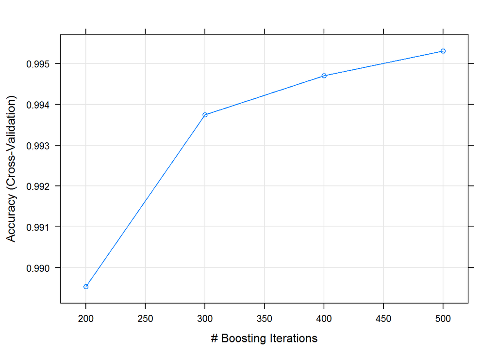

```r
plot(fit2)
```

The following results show how well the second model fits the data:

```r
fit2
```

```
## Stochastic Gradient Boosting
##
## 14718 samples
##    52 predictor
##     5 classes: 'A', 'B', 'C', 'D', 'E'
##
## No pre-processing
## Resampling: Cross-Validated (10 fold)
## Summary of sample sizes: 13246, 13247, 13245, 13247, 13246, 13245, ...
## Resampling results across tuning parameters:
##
##   n.trees  Accuracy   Kappa
##   200      0.9895367  0.9867652
##   300      0.9937487  0.9920924
##   400      0.9946998  0.9932958
##   500      0.9953114  0.9940693
##
## Tuning parameter 'interaction.depth' was held constant at a value of
##  6
## Tuning parameter 'shrinkage' was held constant at a value of 0.1
##
## Tuning parameter 'n.minobsinnode' was held constant at a value of 10
## Accuracy was used to select the optimal model using  the largest value.
## The final values used for the model were n.trees = 500,
##  interaction.depth = 6, shrinkage = 0.1 and n.minobsinnode = 10.
```

```r
fit2$resample
```

```
##     Accuracy     Kappa Resample
## 1  0.9931973 0.9913962   Fold08
## 2  0.9966033 0.9957030   Fold05
## 3  0.9911625 0.9888215   Fold02
## 4  0.9945615 0.9931215   Fold09
## 5  0.9959267 0.9948480   Fold06
## 6  0.9945689 0.9931293   Fold03
## 7  0.9945689 0.9931293   Fold10
## 8  0.9979620 0.9974221   Fold07
## 9  0.9966010 0.9956999   Fold04
## 10 0.9979620 0.9974224   Fold01
```

```r
confusionMatrix.train(fit2)
```

```
## Cross-Validated (10 fold) Confusion Matrix
##
## (entries are percentual average cell counts across resamples)
##
##           Reference
## Prediction    A    B    C    D    E
##          A 28.4  0.1  0.0  0.0  0.0
##          B  0.0 19.3  0.1  0.0  0.0
##          C  0.0  0.0 17.3  0.1  0.0
##          D  0.0  0.0  0.0 16.2  0.0
##          E  0.0  0.0  0.0  0.0 18.3
##
##  Accuracy (average) : 0.9953
```

```r
predfit2 <- predict(fit2, newdata=x_test)
confusionMatrix(y_test,predfit2)
```

```
## Confusion Matrix and Statistics
##
##           Reference
## Prediction    A    B    C    D    E
##          A 1394    0    1    0    0
##          B    7  935    7    0    0
##          C    0    1  850    4    0
##          D    0    0    3  801    0
##          E    0    0    0    3  898
##
## Overall Statistics
##
##                Accuracy : 0.9947
##                  95% CI : (0.9922, 0.9965)
##     No Information Rate : 0.2857
##     P-Value [Acc > NIR] : < 2.2e-16
##
##                   Kappa : 0.9933
##  Mcnemar's Test P-Value : NA
##
## Statistics by Class:
##
##                      Class: A Class: B Class: C Class: D Class: E
## Sensitivity            0.9950   0.9989   0.9872   0.9913   1.0000
## Specificity            0.9997   0.9965   0.9988   0.9993   0.9993
## Pos Pred Value         0.9993   0.9852   0.9942   0.9963   0.9967
## Neg Pred Value         0.9980   0.9997   0.9973   0.9983   1.0000
## Prevalence             0.2857   0.1909   0.1756   0.1648   0.1831
## Detection Rate         0.2843   0.1907   0.1733   0.1633   0.1831
## Detection Prevalence   0.2845   0.1935   0.1743   0.1639   0.1837
## Balanced Accuracy      0.9974   0.9977   0.9930   0.9953   0.9996
```

# Credits

The source for the data used in this project is: http://groupware.les.inf.puc-rio.br/har.

The data are described at http://groupware.les.inf.puc-rio.br/har#ixzz484VEFWp1 and in more detail in this paper:  
Velloso, E.; Bulling, A.; Gellersen, H.; Ugulino, W.; Fuks, H. Qualitative Activity Recognition of Weight Lifting Exercises. Proceedings of 4th International Conference in Cooperation with SIGCHI (Augmented Human ’13) . Stuttgart, Germany: ACM SIGCHI, 2013. (http://groupware.les.inf.puc-rio.br/public/papers/2013.Velloso.QAR-WLE.pdf)

The method for parallel processing the boosting model used in this report is described by Len Greski on his Github page: https://github.com/lgreski/datasciencectacontent/blob/master/markdown/pml-randomForestPerformance.md.

See also re boosting models: James, Gareth, Daniela Witten, Trevor Hastie, and Robert Tibshirani. *An Introduction to Statistical Learning with Applications in R.* (Springer: New York) 2013.